# Dataset Description

The dataset used for this project has been obtained from https://www.kaggle.com/mlg-ulb/creditcardfraud The data contains transaction details from European Card Holders such most of the features have been reduced by Principal Component Analysis due to privacy issues. The features from V1 to V28 were obtained by PCA meaning that they were scalled before applying PCA. The only features that were not transformed by PCA are Time and Amount. Time indicated the seconds that ellapsed between the transactions, amount gives the value transacted during the transaction. The feature of interest is the Class, that is a binary variable with 1 in case a transaction is fraud and 0 if its legitimate.

```python
import pandas as pd
import plotly
import numpy as np
import time
import seaborn as sns
import matplotlib.pyplot as plt
import plotly.express as px
import plotly.figure_factory as ff
import matplotlib.gridspec as gridspec
import plotly.graph_objs as go
from collections import Counter
import plotly.offline as py
from collections import Counter
import warnings
py.init_notebook_mode(connected=True)
%matplotlib inline
```

```python
import tensorflow as tf
import keras
from sklearn.pipeline import make_pipeline
from sklearn.model_selection import train_test_split, StratifiedKFold, KFold
from sklearn.linear_model import LogisticRegression
from sklearn.svm import SVC
from sklearn.tree import DecisionTreeClassifier
from sklearn.ensemble import RandomForestClassifier, ExtraTreesClassifier
from sklearn.neighbors import KNeighborsClassifier
from sklearn.linear_model import LogisticRegression
from sklearn.metrics import precision_score, recall_score, f1_score, roc_auc_score, accuracy_score, classification_report

warnings.filterwarnings("ignore")
```

The main objective below is to have enough information about the datasets by carrying out an exploratory analysis

```python
df = pd.read_csv('creditcard.csv')
df.head()
```

|  | Time | V1 | V2 | V3 | V4 | V5 | V6 | V7 | V8 | V9 | ... | V21 | V22 | V23 | V24 | V25 | V26 | V27 | V28 | Amount | Class |
| --- | --- | --- | --- | --- | --- | --- | --- | --- | --- | --- | --- | --- | --- | --- | --- | --- | --- | --- | --- | --- | --- |
| 0 | 0.0 | -1.359807 | -0.072781 | 2.536347 | 1.378155 | -0.338321 | 0.462388 | 0.239599 | 0.098698 | 0.363787 | ... | -0.018307 | 0.277838 | -0.110474 | 0.066928 | 0.128539 | -0.189115 | 0.133558 | -0.021053 | 149.62 | 0 |
| 1 | 0.0 | 1.191857 | 0.266151 | 0.166480 | 0.448154 | 0.060018 | -0.082361 | -0.078803 | 0.085102 | -0.255425 | ... | -0.225775 | -0.638672 | 0.101288 | -0.339846 | 0.167170 | 0.125895 | -0.008983 | 0.014724 | 2.69 | 0 |
| 2 | 1.0 | -1.358354 | -1.340163 | 1.773209 | 0.379780 | -0.503198 | 1.800499 | 0.791461 | 0.247676 | -1.514654 | ... | 0.247998 | 0.771679 | 0.909412 | -0.689281 | -0.327642 | -0.139097 | -0.055353 | -0.059752 | 378.66 | 0 |
| 3 | 1.0 | -0.966272 | -0.185226 | 1.792993 | -0.863291 | -0.010309 | 1.247203 | 0.237609 | 0.377436 | -1.387024 | ... | -0.108300 | 0.005274 | -0.190321 | -1.175575 | 0.647376 | -0.221929 | 0.062723 | 0.061458 | 123.50 | 0 |
| 4 | 2.0 | -1.158233 | 0.877737 | 1.548718 | 0.403034 | -0.407193 | 0.095921 | 0.592941 | -0.270533 | 0.817739 | ... | -0.009431 | 0.798278 | -0.137458 | 0.141267 | -0.206010 | 0.502292 | 0.219422 | 0.215153 | 69.99 | 0 |

5 rows × 31 columns

```python
# Good No Null Values!
df.isnull().sum().max()
```

```
0
```

```python
df.Class.value_counts()
```

```
0    284315
1       492
Name: Class, dtype: int64
```

```python
print('No Frauds', round(df['Class'].value_counts()[0]/len(df) * 100,2), '% of the dataset')
print('Frauds', round(df['Class'].value_counts()[1]/len(df) * 100,2), '% of the dataset')
```

```
No Frauds 99.83 % of the dataset
Frauds 0.17 % of the dataset
```

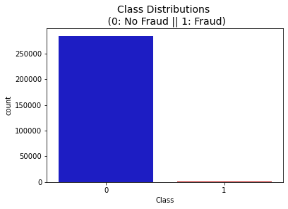

```python
colors = ["#0101DF", "#DF0101"]

sns.countplot('Class', data=df, palette=colors)
plt.title('Class Distributions \n (0: No Fraud || 1: Fraud)', fontsize=14)
```

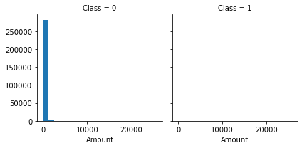

```python
g=sns.FacetGrid(df,col='Class')
g.map(plt.hist,'Amount', bins=20)
```

## Exploratory Data Analysis

```python
fraud_or_not = df["Class"].value_counts().tolist()

labels = ['Not Fraud','Frauds']
values = [fraud_or_not[0], fraud_or_not[1]]
colors = ['skyblue', 'red']

trace = go.Pie(labels=labels, values=values, textinfo='value',
               textfont=dict(size=20),
               marker=dict(colors=colors, line=dict(color='#000000', width=0.1)))

plotly.offline.iplot([trace], filename='styled_pie_chart')
```

[interactive chart not shown]

Its clear that the classes are highly imbalanced and almost all the transactions are not fraudulent. With this class imbalance, the machine learning models might overffit because they might "think" that most of the transactions are actually not fraud and thus this might lead to some errors.

Class imbalance is a quite common problem when working with real-world data—samples from one class or multiple classes are over-represented in a dataset. Intuitively, we can think of several domains where this may occur, such as spam filtering, fraud detection, or screening for diseases.

Because machine learning algorithms often optimize a reward or cost function derived as a total of the training instances seen during fitting, the decision rule is likely to be biased towards the majority class. In other words, the method implicitly develops a model that optimizes predictions based on the most abundant class in the dataset during training in order to reduce cost or maximize reward.

```python
plt.subplots(figsize=(15,12))
sns.heatmap(df.corr(), vmax=.8 , square=True,annot=True,fmt='.2f')
```

[output not shown]

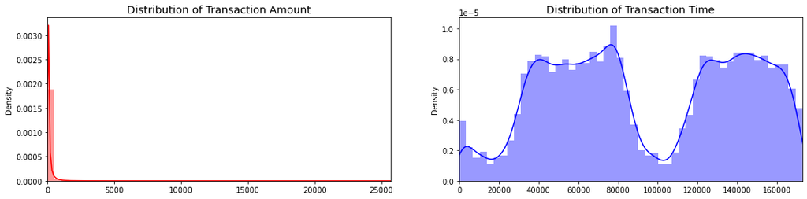

```python
fig, ax = plt.subplots(1, 2, figsize=(18,4))

amount_val = df['Amount'].values
time_val = df['Time'].values

sns.distplot(amount_val, ax=ax[0], color='r')
ax[0].set_title('Distribution of Transaction Amount', fontsize=14)
ax[0].set_xlim([min(amount_val), max(amount_val)])

sns.distplot(time_val, ax=ax[1], color='b')
ax[1].set_title('Distribution of Transaction Time', fontsize=14)
ax[1].set_xlim([min(time_val), max(time_val)])



plt.show()
```

```python
df.columns
```

```
Index(['Time', 'V1', 'V2', 'V3', 'V4', 'V5', 'V6', 'V7', 'V8', 'V9', 'V10',
       'V11', 'V12', 'V13', 'V14', 'V15', 'V16', 'V17', 'V18', 'V19', 'V20',
       'V21', 'V22', 'V23', 'V24', 'V25', 'V26', 'V27', 'V28', 'Amount',
       'Class'],
      dtype='object')
```

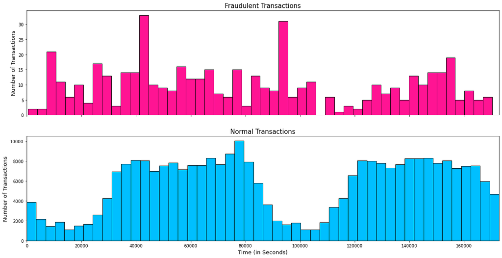

```python
f, (ax1, ax2) = plt.subplots(2, 1, sharex=True, figsize=(20,10))

fraud_transactions = df.Time[df.Class == 1]
normal_transactions = df.Time[df.Class == 0]

ax1.hist(fraud_transactions, bins = 50, color='deeppink', edgecolor="black")
ax1.set_xlim([min(fraud_transactions), max(fraud_transactions)])
ax1.set_title('Fraudulent Transactions', fontsize=15)
ax1.set_ylabel("Number of Transactions",  fontsize=13)

ax2.hist(normal_transactions, bins = 50, color='deepskyblue', edgecolor="black")
ax2.set_xlim([min(normal_transactions), max(normal_transactions)])
ax2.set_title('Normal Transactions',  fontsize=15)

ax2.set_xlabel('Time (in Seconds)',  fontsize=13)
ax2.set_ylabel('Number of Transactions',  fontsize=13)

plt.show()
```

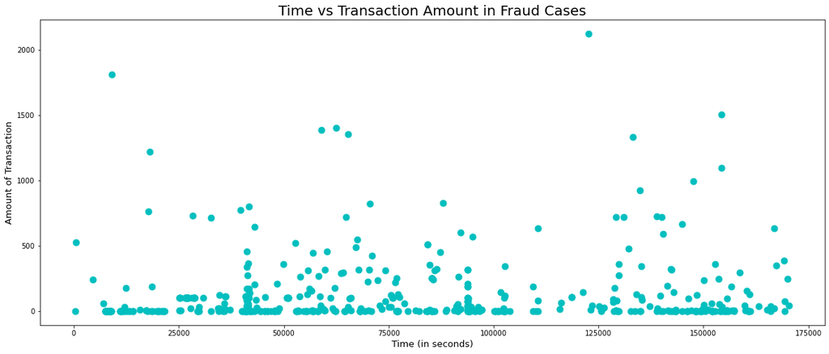

```python
plt.figure(figsize=(20,8))

fig = plt.scatter(x=df[df['Class'] == 1]['Time'], y=df[df['Class'] == 1]['Amount'], color="c", s=80)
plt.title("Time vs Transaction Amount in Fraud Cases", fontsize=20)
plt.xlabel("Time (in seconds)", fontsize=13)
plt.ylabel("Amount of Transaction", fontsize=13)

plt.show()
```

#### A look into the V Features

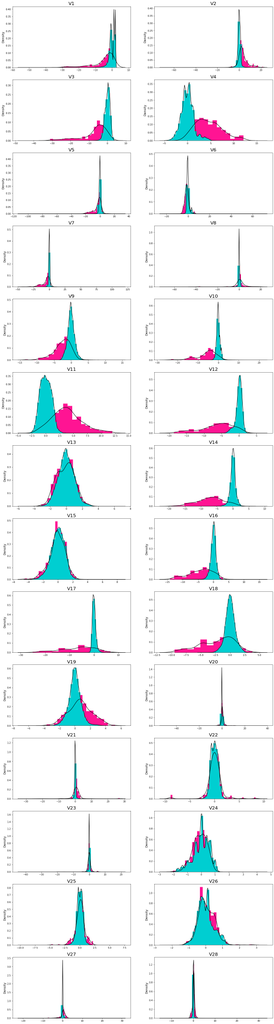

[figure not shown]

```python
#Looking the V's features
columns = df.iloc[:,1:29].columns

frauds = df.Class == 1
normals = df.Class == 0

grid = gridspec.GridSpec(14, 2)
plt.figure(figsize=(20,20*4))

for n, col in enumerate(df[columns]):
    ax = plt.subplot(grid[n])
    sns.distplot(df[col][frauds], color='deeppink', kde_kws={"color": "k", "lw": 1.5},  hist_kws=dict(alpha=1))
    sns.distplot(df[col][normals],color='darkturquoise', kde_kws={"color": "k", "lw": 1.5},  hist_kws=dict(alpha=1))
    ax.set_ylabel('Density', fontsize=13)
    ax.set_title(str(col), fontsize=20)
    ax.set_xlabel('')
plt.show()
```

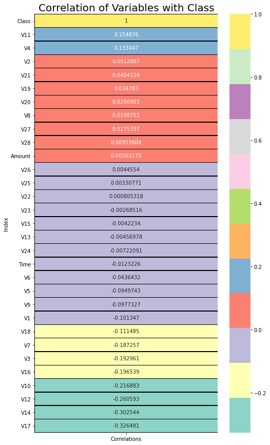

```python
corr = df.corrwith(df['Class']).reset_index()

corr.columns = ['Index','Correlations']
corr = corr.set_index('Index')
corr = corr.sort_values(by=['Correlations'], ascending = False)

plt.figure(figsize=(8, 15))
fig = sns.heatmap(corr, annot=True, fmt="g", cmap='Set3', linewidths=0.4, linecolor='black')

plt.title("Correlation of Variables with Class", fontsize=20)
plt.show()
```

```python
dtf = pd.read_csv('creditcard.csv')
```

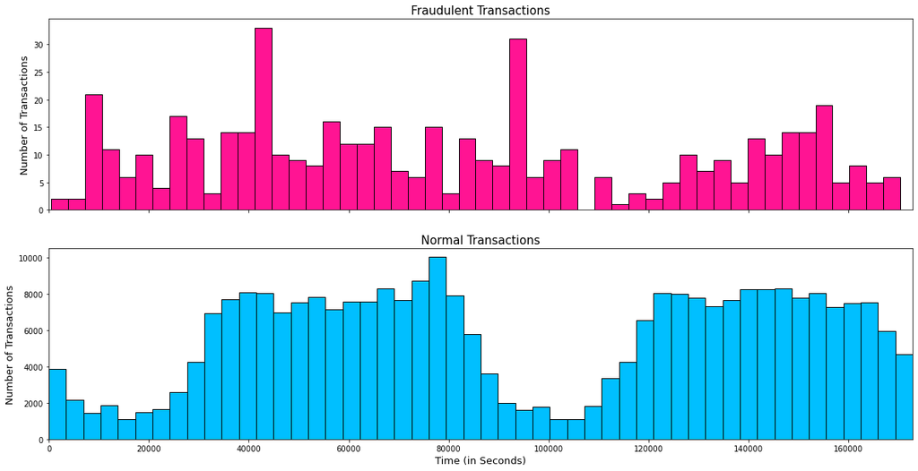

```python
f, (ax1, ax2) = plt.subplots(2, 1, sharex=True, figsize=(20,10))

fraud_transactions = dtf.Time[dtf.Class == 1]
normal_transactions = dtf.Time[dtf.Class == 0]

ax1.hist(fraud_transactions, bins = 50, color='deeppink', edgecolor="black")
ax1.set_xlim([min(fraud_transactions), max(fraud_transactions)])
ax1.set_title('Fraudulent Transactions', fontsize=15)
ax1.set_ylabel("Number of Transactions",  fontsize=13)

ax2.hist(normal_transactions, bins = 50, color='deepskyblue', edgecolor="black")
ax2.set_xlim([min(normal_transactions), max(normal_transactions)])
ax2.set_title('Normal Transactions',  fontsize=15)

ax2.set_xlabel('Time (in Seconds)',  fontsize=13)
ax2.set_ylabel('Number of Transactions',  fontsize=13)

plt.show()
```

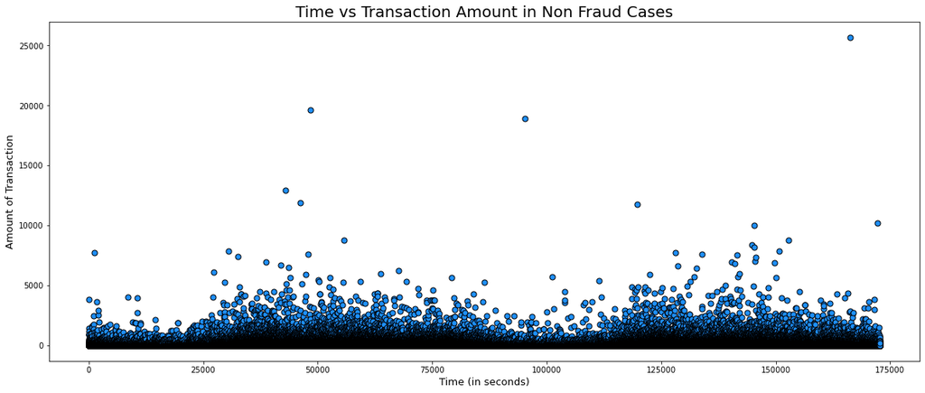

```python
plt.figure(figsize=(20,8))

fig = plt.scatter(x=dtf[dtf['Class'] == 0]['Time'], y=dtf[dtf['Class'] == 0]['Amount'], color="dodgerblue", s=50, edgecolor='black')
plt.title("Time vs Transaction Amount in Non Fraud Cases", fontsize=20)
plt.xlabel("Time (in seconds)", fontsize=13)
plt.ylabel("Amount of Transaction", fontsize=13)

plt.show()
```

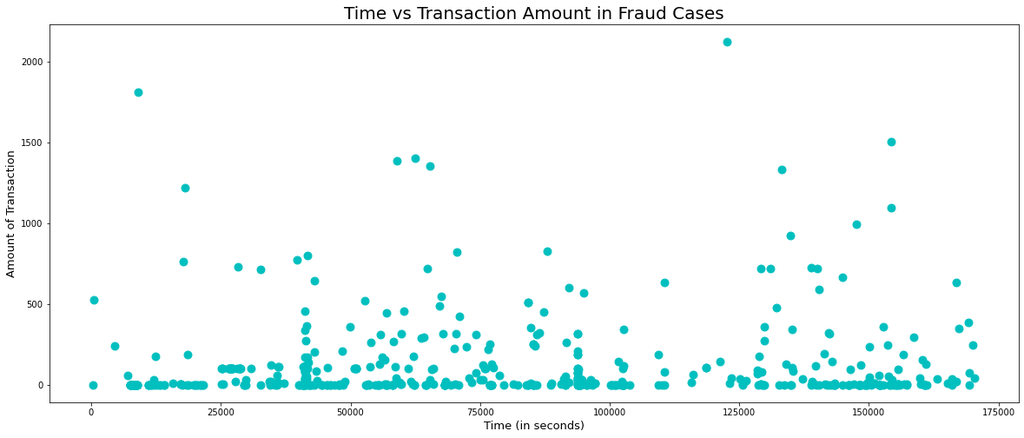

```python
plt.figure(figsize=(20,8))

fig = plt.scatter(x=dtf[dtf['Class'] == 1]['Time'], y=dtf[dtf['Class'] == 1]['Amount'], color="c", s=80)
plt.title("Time vs Transaction Amount in Fraud Cases", fontsize=20)
plt.xlabel("Time (in seconds)", fontsize=13)
plt.ylabel("Amount of Transaction", fontsize=13)

plt.show()
```

```python
timedelta = pd.to_timedelta(df['Time'], unit='s')

df['mins'] = (timedelta.dt.components.minutes).astype(int)
df['hours'] = (timedelta.dt.components.hours).astype(int)
```

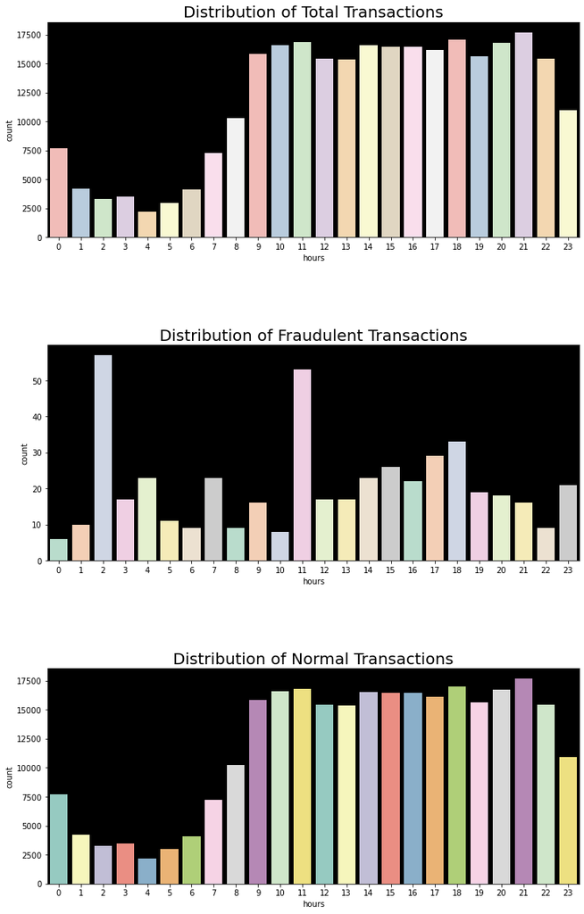

```python
fig, axs = plt.subplots(3, figsize=(12,20))

fig.subplots_adjust(hspace=.5)

sns.countplot(df['hours'], ax = axs[0], palette="Pastel1")
axs[0].set_title("Distribution of Total Transactions",fontsize=20)
axs[0].set_facecolor("black")

sns.countplot(df[(df['Class'] == 1)]['hours'], ax=axs[1], palette='Pastel2')
axs[1].set_title("Distribution of Fraudulent Transactions", fontsize=20)
axs[1].set_facecolor('black')

sns.countplot(df[(df['Class'] == 0)]['hours'], ax=axs[2], palette='Set3')
axs[2].set_title("Distribution of Normal Transactions", fontsize=20)
axs[2].set_facecolor("black")

plt.show()
```

# Outlier Detection

```python
Q3 = np.percentile(df['Amount'], 75)
Q1 = np.percentile(df['Amount'], 25)

# set the cut
cutoff = 5.0

#the interquartile range
IQR = (Q3 - Q1)

# computing lower bound and upper bound
lower_bound = Q1 - (IQR * cutoff)
upper_bound = Q3 + (IQR * cutoff)

#  filter to remove values less than lower bound and greater than
# upper bound
filter_data = (df['Amount'] < lower_bound) | (df['Amount'] > upper_bound)

# filtering data
outliers = df[filter_data]['Amount']
fraud_outliers = df[(df['Class'] == 1) & filter_data]['Amount']
normal_outliers = df[(df['Class'] == 0) & filter_data]['Amount']

print(f"Total Number of Outliers : {outliers.count()}")
print(f"Number of Outliers in Fraudulent Class : {fraud_outliers.count()}")
print(f"No of Outliers in Normal Class : {normal_outliers.count()}")
print(f"Percentage of Fraud amount outliers : {round((fraud_outliers.count()/outliers.count())*100,2)}%")
```

```
Total Number of Outliers : 11366
Number of Outliers in Fraudulent Class : 41
No of Outliers in Normal Class : 11325
Percentage of Fraud amount outliers : 0.36%
```

```python
df = df.drop(outliers.index)
df.reset_index(inplace=True, drop=True)
```

The outliers have now been removed and the machine learning models will not have a problem learning from the features

```python
df.head()
```

[output not shown]

5 rows × 31 columns

## Scaling the Datasets

```python
from imblearn.pipeline import make_pipeline as imbalanced_make_pipeline
from imblearn.over_sampling import SMOTE
from imblearn.under_sampling import NearMiss
from imblearn.metrics import classification_report_imbalanced
```

Up sampling the minority class, down sampling the majority class, and the fabrication of synthetic training samples are some strategies for dealing with class imbalance. Synthetic Minority Over-sampling Technique is the most commonly utilized algorithm for synthetic training sample generation (SMOTE).

The only columns left for scaling are time and amount

```python
from sklearn.preprocessing import StandardScaler, RobustScaler

std_scaler = StandardScaler()
rob_scaler = RobustScaler()

df['scaled_amount'] = rob_scaler.fit_transform(df['Amount'].values.reshape(-1,1))
df['scaled_time'] = rob_scaler.fit_transform(df['Time'].values.reshape(-1,1))

df.drop(['Time','Amount'], axis=1, inplace=True)
```

```python
scaled_amount = df['scaled_amount']
scaled_time = df['scaled_time']

df.drop(['scaled_amount', 'scaled_time'], axis=1, inplace=True)
df.insert(0, 'scaled_amount', scaled_amount)
df.insert(1, 'scaled_time', scaled_time)


df.head()
```

[output not shown]

5 rows × 31 columns

### Splitting the initial dataset for testing

Before performing the Random Under sampling technique, the original data frame which is the object df, is to be split. This is done for testing purposes. The models have to be tested on the original datasets but not on the datasets created from sampling techniques. The aim is to fit the model using the dataframes that have been undersampled or oversamples so that the model can detect patterns, and then test the models on the original datasets.

Since the data is imbalanced, the Stratified K-Fold split will be used.

```python
from sklearn.model_selection import train_test_split
from sklearn.model_selection import StratifiedShuffleSplit

print('No Frauds', round(df['Class'].value_counts()[0]/len(df) * 100,2), '% of the dataset')
print('Frauds', round(df['Class'].value_counts()[1]/len(df) * 100,2), '% of the dataset')
```

```
No Frauds 99.84 % of the dataset
Frauds 0.16 % of the dataset
```

```python
X = df.drop('Class', axis=1)
Y = df['Class']

sss = StratifiedKFold(n_splits=5, random_state=None, shuffle=False)
for train_index, test_index in sss.split(X, Y):
    print("Train:", train_index, "Test:", test_index)
    original_Xtrain, original_Xtest = X.iloc[train_index], X.iloc[test_index]
    original_Ytrain, original_Ytest = Y.iloc[train_index], Y.iloc[test_index]

# Turn into an array
## The variable names original_Xtrain,Xtest, Ytest, Ytrain has been used to mean that the
## train and tests are from the initial dataframe and not the sampled data frames
original_Xtrain = original_Xtrain.values
original_Xtest = original_Xtest.values
original_Ytrain = original_Ytrain.values
original_Ytest = original_Ytest.values

# See if both the train and test label distribution are similarly distributed
train_unique_label, train_counts_label = np.unique(original_Ytrain, return_counts=True)
test_unique_label, test_counts_label = np.unique(original_Ytest, return_counts=True)
print('-' * 100)

print('Label Distributions: \n')
print(train_counts_label/ len(original_Ytrain))
print(test_counts_label/ len(original_Ytest))
```

```
Train: [ 29350  29392  29422 ... 273438 273439 273440] Test: [    0     1     2 ... 54742 54743 54744]
Train: [     0      1      2 ... 273438 273439 273440] Test: [ 29350  29392  29422 ... 109415 109416 109417]
Train: [     0      1      2 ... 273438 273439 273440] Test: [ 76259  76295  76304 ... 164124 164125 164126]
Train: [     0      1      2 ... 273438 273439 273440] Test: [144542 144548 144549 ... 218769 218770 218771]
Train: [     0      1      2 ... 218769 218770 218771] Test: [203831 204371 204395 ... 273438 273439 273440]
----------------------------------------------------------------------------------------------------
Label Distributions:

[0.99834974 0.00165026]
[0.9983543 0.0016457]
```

From the illustration above, the labels for training and testing are balanced by using the Stratified Split.

### Random under sampling technique

Random undersampling is done on the majority class in a data frame so that it matches the distribution of the minority classes that are to be predicted. Otherwise, training or making a model learn from the imbalanced data would result to overfitting or poor correlations amongst the independent and dependent variable.

```python
## Equal probability of selection from the data frame
df = df.sample(frac=1)

# amount of fraud classes 492 rows.
fraud = df.loc[df['Class'] == 1]
non_fraud = df.loc[df['Class'] == 0][:492]

normal_distributed_df = pd.concat([fraud, non_fraud])

# And then Shuffle dataframe rows
new_df = normal_distributed_df.sample(frac=1, random_state=42)

new_df.head()
```

|  | scaled_amount | scaled_time | V1 | V2 | V3 | V4 | V5 | V6 | V7 | V8 | ... | V20 | V21 | V22 | V23 | V24 | V25 | V26 | V27 | V28 | Class |
| --- | --- | --- | --- | --- | --- | --- | --- | --- | --- | --- | --- | --- | --- | --- | --- | --- | --- | --- | --- | --- | --- |
| 251846 | -0.251852 | 0.889679 | 0.567539 | 3.309385 | -6.631268 | 6.394574 | -0.054172 | -2.396535 | -2.792489 | 0.514811 | ... | 0.555412 | 0.614221 | -0.365047 | -0.180409 | -0.523271 | 0.645054 | 0.246466 | 0.902675 | 0.473571 | 1 |
| 150710 | 2.734815 | 0.287491 | -1.000611 | 3.346850 | -5.534491 | 6.835802 | -0.299803 | 0.095951 | -2.440419 | 1.286301 | ... | 1.189814 | 0.439757 | -0.694099 | 0.299660 | -0.657601 | 0.101648 | 0.430457 | 0.824685 | 0.326952 | 1 |
| 70657 | -0.205597 | -0.346512 | 1.535012 | -0.707702 | 0.074725 | -1.217884 | -1.336797 | -1.654706 | -0.403627 | -0.488241 | ... | -0.339427 | -0.134744 | 0.053937 | -0.016961 | 0.930563 | 0.630702 | -0.117133 | 0.002398 | 0.012025 | 0 |
| 8077 | -0.312593 | -0.866820 | -2.125490 | 5.973556 | -11.034727 | 9.007147 | -1.689451 | -2.854415 | -7.810441 | 2.030870 | ... | 1.493775 | 1.646518 | -0.278485 | -0.664841 | -1.164555 | 1.701796 | 0.690806 | 2.119749 | 1.108933 | 1 |
| 50355 | -0.312593 | -0.461816 | -1.519244 | 2.308492 | -1.503599 | 2.064101 | -1.000845 | -1.016897 | -2.059731 | -0.275166 | ... | 0.175019 | 1.307871 | 0.102826 | -0.017746 | 0.149696 | -0.096602 | -0.369115 | -0.019244 | -0.208319 | 1 |

5 rows × 31 columns

#### Checking the distribution of the data

```
Distribution of the Classes in the subsample dataset
0    0.521739
1    0.478261
Name: Class, dtype: float64
```

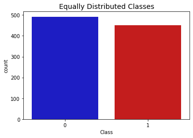

```python
print('Distribution of the Classes in the subsample dataset')
print(new_df['Class'].value_counts()/len(new_df))


sns.countplot('Class', data=new_df, palette=colors)
plt.title('Equally Distributed Classes', fontsize=14)
plt.show()
```